# Final Project

Nathan Holterhoff, Taylor Kelly, Anthony Liu

2024-05-31

```r
file_path <- 'IAC_Database_20240514.xlsx'
sheet_names <- excel_sheets(file_path)

naics_codes <-  read_excel("2-6 digit_2022_Codes.xlsx")
arc_codes <- read.csv('ARC_List_Full_Extracted.csv')

arc_codes <- arc_codes %>%
  select(Code, Description)


# names(naics_codes)
# naics_codes <- read.csv("naics.csv")
naics_codes <- naics_codes %>%
  select("2022 NAICS US   Code", "2022 NAICS US Title")
names(naics_codes)[names(naics_codes) == "2022 NAICS US   Code"] <- 'NAICS'
names(naics_codes)[names(naics_codes) == "2022 NAICS US Title"] <- 'US_TITLE'
naics_codes$NAICS <- as.numeric(naics_codes$NAICS)
head(naics_codes)
```

```
## # A tibble: 6 × 2
##    NAICS US_TITLE
##    <dbl> <chr>
## 1     NA <NA>
## 2     11 Agriculture, Forestry, Fishing and Hunting
## 3    111 Crop Production
## 4   1111 Oilseed and Grain Farming
## 5  11111 Soybean Farming
## 6 111110 Soybean Farming
```

```r
# Initialize a list to hold all data frames
data_frames <- list()

# Loop through each sheet name and read the sheet into a data frame
for (sheet_name in sheet_names) {
  data_frames[[sheet_name]] <- read_excel(file_path, sheet = sheet_name, guess_max = 10000)
}
head(data_frames)
```

```
## $ASSESS
## # A tibble: 21,325 × 55
##    ID     CENTER    FY   SIC NAICS STATE    SALES EMPLOYEES PLANT_AREA PRODUCTS
##    <chr>  <chr>  <dbl> <dbl> <dbl> <chr>    <dbl>     <dbl>      <dbl> <chr>
##  1 AM0001 AM      1987  3671    NA TX    33900000       206         NA MICRO & …
##  2 AM0002 AM      1987  2761    NA TX    25000000       156         NA BUSINESS…
##  3 AM0003 AM      1987  3494    NA TX    15000000       200         NA SAFETY J…
##  4 AM0004 AM      1987  3713    NA TX     4200000        75         NA TRUCKS B…
##  5 AM0005 AM      1987  2024    NA TX    12000000        39         NA ICE CREAM
##  6 AM0006 AM      1987  2048    NA TX    11000000        50         NA FEED & M…
##  7 AM0007 AM      1987  3559    NA TX    25000000        75         NA NG LIQUI…
##  8 AM0008 AM      1987  2448    NA TX     1900000        50         NA WOODEN P…
##  9 AM0009 AM      1987  2796    NA TX    22000000        82         NA LIGHOGRA…
## 10 AM0010 AM      1987  2752    NA TX    30000000       312         NA LETHOGRA…
## # ℹ 21,315 more rows
## # ℹ 45 more variables: PRODUNITS <dbl>, PRODLEVEL <dbl>, PRODHOURS <dbl>,
## #   NUMARS <dbl>, EC_plant_cost <dbl>, EC_plant_usage <dbl>,
## #   ED_plant_cost <dbl>, ED_plant_usage <dbl>, EF_plant_cost <dbl>,
## #   E2_plant_cost <dbl>, E2_plant_usage <dbl>, E3_plant_cost <dbl>,
## #   E3_plant_usage <dbl>, E4_plant_cost <dbl>, E4_plant_usage <dbl>,
## #   E5_plant_cost <dbl>, E5_plant_usage <dbl>, E6_plant_cost <dbl>, …
##
## $RECC1
## # A tibble: 30,000 × 30
##    SUPERID ID    AR_NUMBER APPCODE  ARC2 IMPSTATUS IMPCOST PSOURCCODE PCONSERVED
##    <chr>   <chr>     <dbl>   <dbl> <dbl> <chr>       <dbl> <chr>           <dbl>
##  1 AM0001… AM00…         1      NA  2.81 N           15000 E1                 NA
##  2 AM0001… AM00…         2      NA  2.71 N             189 E1               7034
##  3 AM0001… AM00…         3      NA  2.71 N             398 E1              10258
##  4 AM0001… AM00…         4      NA  2.74 I             354 E1              10844
##  5 AM0001… AM00…         5      NA  2.72 N              15 E1               4982
##  6 AM0001… AM00…         6      NA  2.71 N              NA E1               1758
##  7 AM0001… AM00…         7      NA  2.71 N              NA E1                586
##  8 AM0002… AM00…         1      NA  2.62 I            5500 E1             260844
##  9 AM0002… AM00…         2      NA  2.72 I           60000 E1            1077960
## 10 AM0002… AM00…         3      NA  2.62 I              NA E1               4689
## # ℹ 29,990 more rows
## # ℹ 21 more variables: PSOURCONSV <dbl>, PSAVED <dbl>, SSOURCCODE <chr>,
## #   SCONSERVED <dbl>, SSOURCONSV <dbl>, SSAVED <dbl>, TSOURCCODE <chr>,
## #   TCONSERVED <dbl>, TSOURCONSV <dbl>, TSAVED <dbl>, QSOURCCODE <chr>,
```

[output cut: 76 more lines]

```
##  3 TN0599… TN05…         2       4  3.12 N              NA W4             115000
##  4 TN0599… TN05…         3       1  3.53 N           32900 P2                 NA
##  5 TN0599… TN05…         4       4  3.12 N              NA W4             360000
##  6 TN0599… TN05…         5       3  2.73 N            3400 E2               2670
##  7 TN0599… TN05…         6       3  2.71 N            1000 EC              38101
##  8 TN0599… TN05…         7       2  2.42 N            1110 ED                108
##  9 TN0600… TN06…         1       4  4.42 N           10000 P1                 NA
## 10 TN0600… TN06…         2       4  3.12 I            9000 W4             570000
## # ℹ 29,990 more rows
## # ℹ 21 more variables: PSOURCONSV <dbl>, PSAVED <dbl>, SSOURCCODE <chr>,
## #   SCONSERVED <dbl>, SSOURCONSV <dbl>, SSAVED <dbl>, TSOURCCODE <chr>,
## #   TCONSERVED <dbl>, TSOURCONSV <dbl>, TSAVED <dbl>, QSOURCCODE <chr>,
## #   QCONSERVED <dbl>, QSOURCONSV <dbl>, QSAVED <dbl>, REBATE <chr>,
## #   INCREMNTAL <chr>, FY <dbl>, IC_CAPITAL <dbl>, IC_OTHER <dbl>,
## #   PAYBACK <dbl>, BPTOOL <chr>
```

# Abstract

This report analyzes energy assessment data from Industrial Assessment Centers (IACs) to identify energy savings opportunities across varied industries in Washington. By leveraging detailed statistical analysis and data visualizations, we examined energy consumption trends and efficiency recommendations. Key findings reveal significant potential savings, particularly in Washington state. Our analysis highlights critical areas where energy efficiency can be markedly improved, providing a targeted roadmap for future IAC assessments and initiatives.

# Introduction

The Industrial Assessment Centers (IAC) program plays a crucial role in helping small and medium-sized manufacturers in the United States enhance their energy efficiency, productivity, and waste reduction efforts. The IAC data offers a comprehensive overview of various assessments, recommendations, and implementations aimed at achieving these goals. By examining the IAC data, we can uncover patterns and insights that may lead to improved practices in energy management and sustainability within the manufacturing sector in Washington state.

Existing literature and media highlight the importance of energy efficiency and waste reduction as key components of sustainable manufacturing. The IAC program, funded by the Department of Energy, has been instrumental in providing no-cost technical assessments to small and medium-sized enterprises (SMEs) across the U.S. Studies have shown that the recommendations from IAC assessments result in substantial energy savings and cost reductions for participating manufacturers. Additionally, there is a growing trend toward adopting advanced technologies and practices to enhance efficiency and reduce environmental impact in manufacturing.

Our analysis of the IAC dataset aims to answer several key questions that can provide valuable insights into the program’s effectiveness and the broader implications for sustainable manufacturing. Firstly, we seek to identify the most common recommendations provided by IAC assessments and how they vary across different industries in Washington state. Secondly, we aim to quantify the total cost savings and energy savings achieved by assessments and centers, examining how these metrics vary by region. Thirdly, we will explore the ratio of sales and savings of IAC companies over time and the factors influencing these rates.

This analysis is significant for several reasons. It can inform policymakers and stakeholders about the effectiveness of the IAC program and help shape future energy efficiency initiatives. Manufacturers can benefit from understanding which recommendations have been most effective in similar contexts, aiding in the adoption of best practices. Furthermore, this study contributes to broader efforts to reduce the environmental impact of manufacturing industries, aligning with global sustainability goals. By identifying cost-saving measures, this research can also help manufacturers reduce operational costs, thereby improving their competitiveness and financial health. Ultimately, this analysis will provide valuable insights into the IAC program’s impact, guiding future improvements and fostering a more sustainable manufacturing sector.

# Data

### Explanation of the Data

We chose these datasets because they offers valuable insights into the effectiveness of the IAC recommendations. By analyzing this data, we can identify common areas for improvement in manufacturing processes, quantify the financial and energy savings achieved, and inform future energy efficiency initiatives. This analysis is particularly relevant given the increasing emphasis on sustainability and efficient resource utilization in manufacturing.

The data is freely available to the public and can be accessed through the IAC’s official website: [IAC Database](https://iac.university/). There are no restrictions on the use of this data, making it accessible for both academic and commercial purposes. The dataset covers various aspects of the IAC assessments, including details about the assessments, the recommendations provided, and the implementation status of those recommendations. The population for this dataset includes small and medium-sized manufacturers across the United States that have received assessments from the IAC program.

While the datasets are comprehensive, they do have some data quality issues. There are inconsistent data entries and changes to the structure over the last 30 years. There is missing data for certain assessments or recommendations, and a time lag between when assessments are conducted and when the data is entered into the database. Since the data has been collected over 30 years, some metrics have changed within the program and more recent assignments are more detailed than prior assessments. Despite these issues, the dataset remains a valuable resource for analyzing energy efficiency practices in the manufacturing sector.

## Introduction to the Data

This report analyzes datasets provided by the Industrial Assessment Centers (IAC) program. These datasets are instrumental for studying energy efficiency practices and their outcomes in the manufacturing sector.

### Source and Data Availability

- **Collector**: Data collected by the Industrial Assessment Centers (IAC), supported by the Department of Energy.
- **Access**: Data is publicly available and can be accessed here: [IAC Database](https://iac.university/). There are no restrictions on its use, making it available for both academic and commercial purposes.

### Dataset Overview

- **Content**: The dataset includes detailed records from energy assessments across various manufacturing sites:
  - `ASSESS`: General information about each assessment.
  - `RECC1 to RECC6`: Specific energy-saving recommendations.
  - `Terms`: Definitions and terminologies used within the dataset.
- **Population and Sample**:
  - **Population**: Small and medium-sized manufacturing facilities in the U.S.
  - **Sample**: Each record represents an individual assessment conducted by the IAC.

## Data Explanation and Description

### Data Structure and Quality

**Dimensions and Structure**: - **Total Sheets**: 8, including details and recommendations. - **General Dimensions**: - ASSESS sheet: 21325 rows x 55 columns - RECC sheets: Each approximately 30000 rows x 30 columns

**Variables and Coding**: - **Key Variables**: Include identifiers, dates, types of recommendations, potential and actual savings, implementation status. - **Coding**: Numerically and categorically coded variables. - **Column names**:

The Column for ACCESS can be seen below

```r
for (i in 1:nrow(data_frames[['Terms']])){
  cat(data_frames[['Terms']][['ASSESS Terms']][i],": ", data_frames[['Terms']][[2]][i], '\n')
}
```

```
## ID :  Assessment ID
## CENTER :  IAC Center Code
## FY :  Fiscal Year
## SIC :  SIC industrial classification code
## NAICS :  NAICS industrial classification code
## STATE :  US State abbreviation
## SALES :  Total yearly sales
## EMPLOYEES :  Total site employees
## PLANT_AREA :  Total plant square footage
## PRODUCTS :  Types of products
## PRODUNITS :  Production level units
## PRODLEVEL :  Total yearly production
## PRODHOURS :  Total yearly hours of operation
## NUMARS :  Total number of recommendations
## EC_plant_cost :  Total yearly electricity consumption costs ($)
## EC_plant_usage :  Total yearly electricity consumption (kWh)
## ED_plant_cost :  Total yearly electricity demand charges ($)
## ED_plant_usage :  Total yearly electricity demand (kW-month-year)
## EF_plant_cost :  Total yearly electricity fees
## E2_plant_cost :  Total yearly natrual gas consumption costs ($)
## E2_plant_usage :  Total yearly natural gas consumption (MMBtu)
## E3_plant_cost :  Total yearly LPG consumption costs ($)
## E3_plant_usage :  Total yearly LPG consumption (MMBtu)
## E4_plant_cost :  Total yearly #1 Fuel Oil consumption costs ($)
## E4_plant_usage :  Total yearly #1 Fuel Oil consumption (MMBtu)
## E5_plant_cost :  Total yearly #2 Fuel Oil consumption costs ($)
## E5_plant_usage :  Total yearly #2 Fuel Oil consumption (MMBtu)
## E6_plant_cost :  Total yearly #4 Fuel Oil consumption costs ($)
## E6_plant_usage :  Total yearly #4 Fuel Oil consumption (MMBtu)
## E7_plant_cost :  Total yearly #6 Fuel Oil consumption costs ($)
## E7_plant_usage :  Total yearly #6 Fuel Oil consumption (MMBtu)
## E8_plant_cost :  Total yearly Coal consumption costs ($)
## E8_plant_usage :  Total yearly Coal consumption (MMBtu)
## E9_plant_cost :  Total yearly Wood  consumption costs ($)
## E9_plant_usage :  Total yearly Wood consumption (MMBtu)
## E10_plant_cost :  Total yearly Paper consumption costs ($)
## E10_plant_usage :  Total yearly Paper consumption (MMBtu)
## E11_plant_cost :  Total yearly Other Gas consumption costs ($)
## E11_plant_usage :  Total yearly Other Gas consumption (MMBtu)
## E12_plant_cost :  Total yearly Other Energy consumption costs ($)
## E12_plant_usage :  Total yearly Other Energy consumption (MMBtu)
## W0_plant_cost :  Total yearly Water consumption costs ($)
## W0_plant_usage :  Total yearly Water consumption (Tgal)
## W1_plant_cost :  Total yearly Water disposal costs ($)
## W1_plant_usage :  Total yearly Water disposal (gal)
## W2_plant_cost :  Total yearly Other Liquid (non-haz) disposal costs ($)
## W2_plant_usage :  Total yearly Other Liquid (non-haz) disposal (gal)
## W3_plant_cost :  Total yearly Other Liquid (haz) disposal costs ($)
## W3_plant_usage :  Total yearly Other Liquid (haz) disposal (gal)
## W4_plant_cost :  Total yearly Other Solid (non-haz) disposal costs ($)
## W4_plant_usage :  Total yearly Other Solid (non-haz) disposal (lbs)
## W5_plant_cost :  Total yearly Other Solid (haz) disposal costs ($)
## W5_plant_usage :  Total yearly Other Solid (haz) disposal (lbs)
## W6_plant_cost :  Total yearly Gaseous Waste disposal costs ($)
## W6_plant_usage :  Total yearly Gaseous Waste disposal (lbs)
```

The Column for RECC can be seen below

```r
for (i in 1:nrow(data_frames[['Terms']])) {
  term <- data_frames[['Terms']][['RECC Terms']][i]
  description <- data_frames[['Terms']][[5]][i]
  if (!is.na(term) && !is.na(description)) {
    cat(term, ": ", description, '\n')
  }
}
```

```
## SUPERID :  Assessment ID + Recommendation Number
## ID :  Assessment ID
## AR_NUMBER :  Recommendation Number
## APPCODE :  Application Code
## ARC2 :  IAC Assessment Recommendation Code
## IMPSTATUS :  Implementation Status (I = implemented, N= Not Implement)
## IMPCOST :  Total implementation cost
## PSOURCCODE :  Primary resource identification code
## PCONSERVED :  Units conserved
## PSOURCONSV :  Source units conserved
## PSAVED :  Cost savings
## SSOURCCODE :  Secondary resource identification code
## SCONSERVED :  Units conserved
## SSOURCONSV :  Source units conserved
## SSAVED :  Cost savings
## TSOURCCODE :  Tertiary resource identification code
## TCONSERVED :  Units conserved
## TSOURCONSV :  Source units conserved
## TSAVED :  Cost savings
## QSOURCCODE :  Quaternary resource identification code
## QCONSERVED :  Units conserved
## QSOURCONSV :  Source units conserved
## QSAVED :  Cost savings
## REBATE :  Was a rebate involved (yes/no)
## INCREMNTAL :  Was the recommendation implemented incrementally (yes/no)
## FY :  Fiscal Year
## IC_CAPITAL :  Captial component of implementation cost
## IC_OTHER :  Other componenet of implementation cost
## PAYBACK :  Simple Payback (years)
## BPTOOL :  What best practice tools was used (if any)
```

**Data Quality Issues**: - **Missing Data**: Notable in implementation status and metrics. - **Inconsistencies and Anomalies**: Variability in entries and some columns with mixed data types.

### Handling Data Quality Issues

To ensure the integrity of our analysis:

- **Consistency Checks**: All columns were presented in the same format with similar data structures.
- **Missing Data Handling**: We only selected columns that were needed for the calculation and removed rows that contained NAs.
- **Data Conversion**: Convert mixed-type columns to text or numeric in cleanup based on column type.

## Methods

### Data Selection and Variables Included

The analysis primarily focused on data provided by Industrial Assessment Centers (IACs), which conduct assessments to identify potential energy savings, waste reduction, and productivity improvements in manufacturing. The variables selected for inclusion were:

- **US_TITLE (Industry Title)** and **NAICS (North American Industry Classification System) codes**: Used to categorize assessments by industry type, allowing for sector-specific analysis.
- **ARC2 (Assessment Recommendation Code)**: Included to evaluate specific energy-saving recommendations and their impacts.
- **PSAVED, SSAVED, TSAVED, QSAVED (Projected Savings from various sources)**: These variables represent the estimated savings from implemented recommendations, crucial for calculating total potential savings.

Variables were chosen based on their relevance to energy consumption and savings potential.

### Sample Selection

The sample included all available assessments from IACs across the United States to maximize generalizability and applicability across the manufacturing sector.

### Statistical Methods and Technical Decisions

- **Descriptive Analysis**: Calculating descriptive statistics to understand the key variables’ distribution.
- **Bar Graphs and Visualizations**: Employed for displaying the impact of different recommendations across industries.
- **Top Five Analysis**: Focused on the top five industries and recommendations based on count and potential savings.

### Trade-offs and Decision Rationale

This methods section outlines the steps taken to prepare, process, and analyze the IAC data, emphasizing maintaining data integrity and relevance to the study’s goals. The chosen methods balance thoroughness with practical constraints, aiming to provide insightful and actionable results.

# Graphs and Setup

## Setting up Dataframe

We needed to create a sub tibble in order to stack the assessment sheets into one dataframe. We keep all variables for this.

```r
all_reccs <- tibble()
for(sheet_name in sheet_names[2:7]){
  print(sheet_name)
  all_reccs <- bind_rows(all_reccs, data_frames[[sheet_name]])
}
```

```
## [1] "RECC1"
## [1] "RECC2"
## [1] "RECC3"
## [1] "RECC4"
## [1] "RECC5"
## [1] "RECC6"
```

```r
nrow(all_reccs)
```

```
## [1] 159028
```

```r
print(sheet_names)
```

```
## [1] "ASSESS" "RECC1"  "RECC2"  "RECC3"  "RECC4"  "RECC5"  "RECC6"  "Terms"
```

## Joining the Data

Here we created the dataframe and joined the Assess sheet, the combined recc sheet, the NACIS sheet, and the ARC code sheet. We cleaned the data by making all the states abbrivations uppercase and combining the Fiscal year columns that were duplicated in the database.

```r
joined_frames <- left_join(data_frames[["ASSESS"]], naics_codes, "NAICS")
all_reccs <- left_join(all_reccs, arc_codes, c("ARC2"= "Code"))
joined_frames <- left_join(joined_frames, all_reccs, "ID")
joined_frames <- joined_frames %>%
  mutate(STATE = toupper(STATE)) %>%
  select(!FY.y)

joined_frames$STATE <- toupper(joined_frames$STATE)
names(joined_frames)[names(joined_frames) == 'FY.x'] <- 'FY'
head(joined_frames)
```

```
## # A tibble: 6 × 85
##   ID     CENTER    FY   SIC NAICS STATE    SALES EMPLOYEES PLANT_AREA PRODUCTS
##   <chr>  <chr>  <dbl> <dbl> <dbl> <chr>    <dbl>     <dbl>      <dbl> <chr>
## 1 AM0001 AM      1987  3671    NA TX    33900000       206         NA MICRO & M…
## 2 AM0001 AM      1987  3671    NA TX    33900000       206         NA MICRO & M…
## 3 AM0001 AM      1987  3671    NA TX    33900000       206         NA MICRO & M…
## 4 AM0001 AM      1987  3671    NA TX    33900000       206         NA MICRO & M…
## 5 AM0001 AM      1987  3671    NA TX    33900000       206         NA MICRO & M…
## 6 AM0001 AM      1987  3671    NA TX    33900000       206         NA MICRO & M…
## # ℹ 75 more variables: PRODUNITS <dbl>, PRODLEVEL <dbl>, PRODHOURS <dbl>,
## #   NUMARS <dbl>, EC_plant_cost <dbl>, EC_plant_usage <dbl>,
## #   ED_plant_cost <dbl>, ED_plant_usage <dbl>, EF_plant_cost <dbl>,
## #   E2_plant_cost <dbl>, E2_plant_usage <dbl>, E3_plant_cost <dbl>,
## #   E3_plant_usage <dbl>, E4_plant_cost <dbl>, E4_plant_usage <dbl>,
## #   E5_plant_cost <dbl>, E5_plant_usage <dbl>, E6_plant_cost <dbl>,
## #   E6_plant_usage <dbl>, E7_plant_cost <dbl>, E7_plant_usage <dbl>, …
```

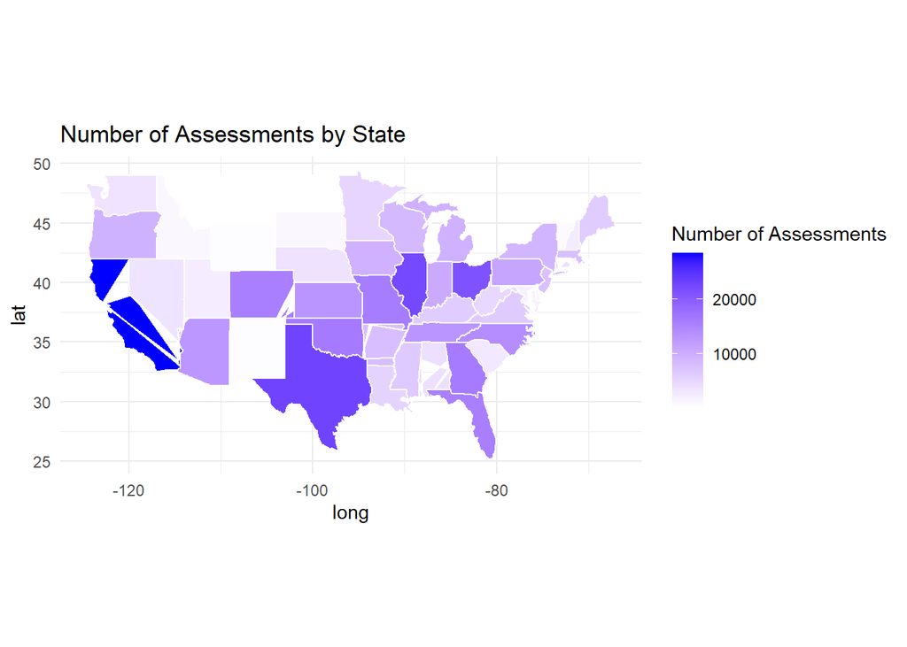

```r
state_lookup <- data.frame(
  abbrev = state.abb,
  full_name = state.name
)

# Ensure the names are in lowercase for consistent matching
state_lookup$abbrev <- tolower(state_lookup$abbrev)
state_lookup$full_name <- tolower(state_lookup$full_name)

state_summary <- joined_frames %>%
  group_by(STATE) %>%
  summarise(assessments = n(), .groups = 'drop')  # Count of assessments


state_summary <- state_summary %>%
  mutate(region = tolower(STATE)) %>%
  left_join(state_lookup, by = c("region" = "abbrev")) %>%
  mutate(region = ifelse(is.na(full_name), region, full_name)) %>%
  select(-full_name, -STATE)  # Clean up unnecessary columns

# Get state map data
states_map <- map_data("state")
states_map$region <- tolower(states_map$region)

# Merge the summarized data with the map data
map_data <- merge(states_map, state_summary, by = "region", all.x = TRUE)

# Create the choropleth map
choropleth_map <- ggplot(map_data, aes(long, lat, group = group, fill = assessments)) +
  geom_polygon(color = "white") +
  scale_fill_gradient(low = "white", high = "blue", na.value = "grey") +
  coord_fixed(1.3) +
  labs(fill = "Number of Assessments") +
  ggtitle("Number of Assessments by State") +
  theme_minimal()

print(choropleth_map)
```

## Energy Costs by Center Across the USA

```r
# Bar Plot of Total Energy Costs by Plant
# Calculate total energy costs for each center
energy_cost_columns <- c("EC_plant_cost", "E2_plant_cost", "E3_plant_cost", "E4_plant_cost", "E5_plant_cost",
                         "E6_plant_cost", "E7_plant_cost", "E8_plant_cost", "E9_plant_cost", "E10_plant_cost",
                         "E11_plant_cost", "E12_plant_cost")
joined_frames %>%
  filter(is.na(PSAVED)) %>%
  nrow()
```

```
## [1] 505
```

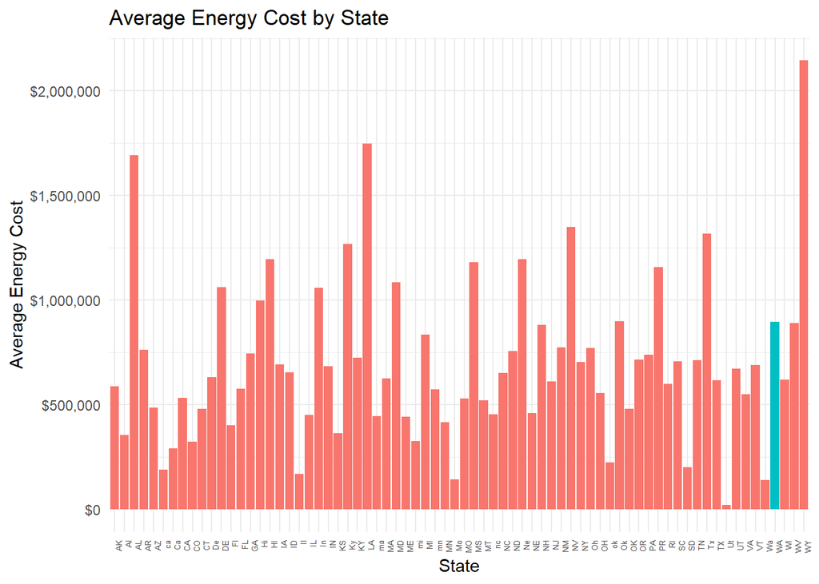

```r
total_saving <- data_frames[["ASSESS"]] %>%
  filter(!is.na(STATE)) %>%
  group_by(ID) %>%
  mutate(total_saving = sum(EC_plant_cost, E2_plant_cost, E3_plant_cost, E4_plant_cost, E5_plant_cost,
                         E6_plant_cost, E7_plant_cost, E8_plant_cost, E9_plant_cost, E10_plant_cost,
                         E11_plant_cost, E12_plant_cost, na.rm = TRUE))


total_saving <-  total_saving %>%
  group_by(STATE) %>%
  summarize(TOTALPSAVED = mean(total_saving))


total_saving %>%
  ggplot(aes(x = STATE, y = TOTALPSAVED, fill = STATE == "WA")) +
  geom_bar(stat = "identity", linewidth = 1, position = position_dodge2()) +
  labs(title = "Average Energy Cost by State",
       x = "State",
       y = "Average Energy Cost",
       fill = "Washington") +
  theme_minimal() +
  theme(axis.text.x = element_text(angle = 90, hjust = 1, size = 5)) +
  theme(legend.position = "none") +
  scale_y_continuous(labels = label_dollar())
```

```r
# +
#   scale_fill_gradient(low = "purple", high = "gold", na.value = "grey")
```

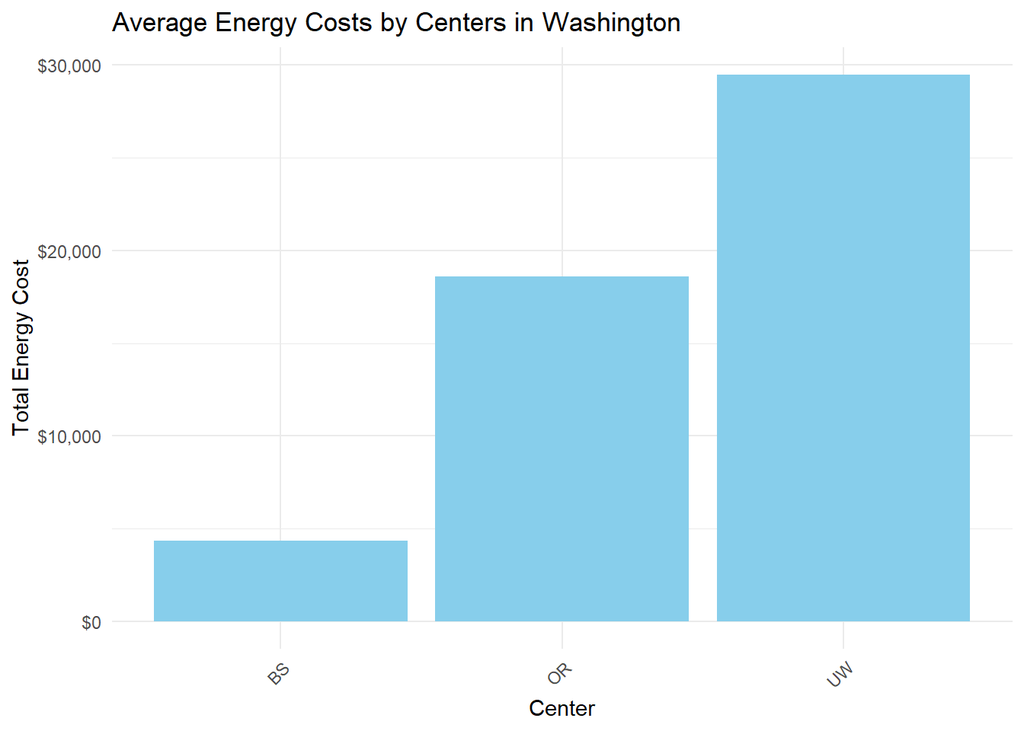

```r
# NEed to tinker, only considers primary resource
total_saving_WA <- joined_frames %>%
  filter(STATE == "WA") %>%
  select(CENTER, PSAVED) %>%
  group_by(CENTER) %>%
  summarize(TOTALPSAVED = mean(PSAVED, na.rm = TRUE)) %>%
  filter(TOTALPSAVED > 0)

total_saving_WA %>%
  ggplot(aes(x = CENTER, y = TOTALPSAVED)) +
  geom_bar(stat = "identity", fill = "skyblue") +
  labs(title = "Average Energy Costs by Centers in Washington",
       x = "Center",
       y = "Total Energy Cost") +
  theme_minimal() +
  theme(axis.text.x = element_text(angle = 45, hjust = 1)) +
  scale_y_continuous(labels = label_dollar())
```

```r
# joined_frames %>%
#   filter(STATE == "WA") %>%
#   group_by(CENTER) %>%
#   count(PSOURCCODE, na.rm = TRUE) %>%
#   filter(n > 25) %>%
#   ggplot(aes(x = CENTER, y = n, fill = PSOURCCODE)) +
#   geom_bar(stat = "identity", , position = position_dodge()) +
#   labs(title = "Washington Centers by Primary Resource",
#        x = "Center",
#        y = "Count of Reports for Energy of that Type",
#        )
#   #scale_fill_manual(values = c("purple", "gold"), scale = PSOURCCODE)
#   # theme_minimal() +
#   # theme(axis.text.x = element_text(angle = 45, hjust = 1))
#   # select(CENTER, PSOURCCODE) %>%
#   # summarize(code_count = count(PSOURCCODE, na.rm = TRUE))
```

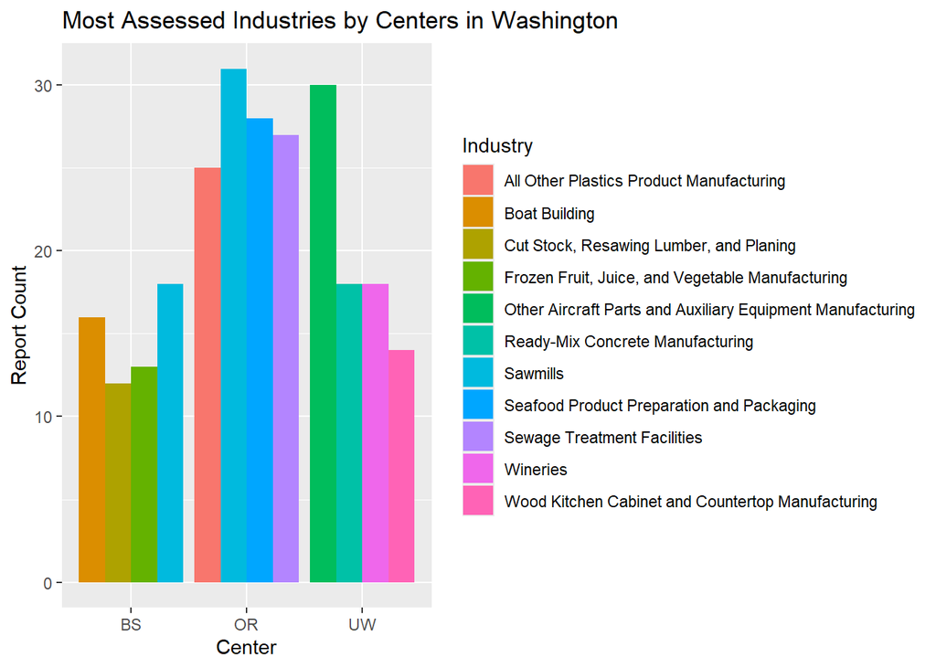

```r
# Highest count NAICS code, grouped by Center
joined_frames %>%
  filter(STATE == "WA") %>%
  select(CENTER, NAICS, STATE, US_TITLE) %>%
  group_by(CENTER) %>%
  na.omit() %>%
  count(US_TITLE, na.rm = TRUE) %>%
  filter(rank(desc(n)) < 5) %>%
  # Change the fill name to the actual product
  ggplot(aes(x = CENTER, y = n, fill = factor(US_TITLE))) +
  geom_bar(stat = "identity", position = position_dodge()) +
  labs(title = "Most Assessed Industries by Centers in Washington",
       x = "Center",
       y = "Report Count",
       fill = "Industry"
       )
```

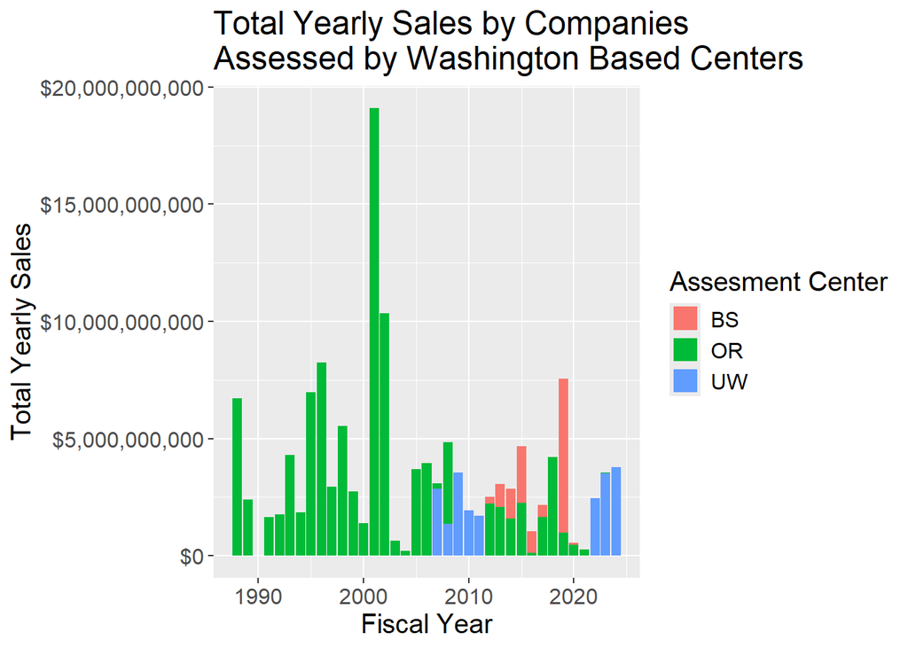

```r
# Tracking Savings per fiscal year
joined_frames %>%
  filter(STATE == "WA") %>%
  select(SUPERID, ID, NAICS, CENTER, SALES, FY) %>%
  filter(!is.na(SALES)) %>%
  group_by(CENTER, FY) %>%
  summarize(SALES_TOTAL = sum(SALES)) %>%
  ggplot(aes(x = FY, y = SALES_TOTAL, fill = CENTER)) +
  geom_bar(stat = "identity", size = 2) +
  ggtitle("Total Yearly Sales by Companies \nAssessed by Washington Based Centers") +
  labs(x = "Fiscal Year",
       y = "Total Yearly Sales",
       fill = "Assesment Center"
       ) +
  scale_y_continuous(labels = label_dollar()) +
  theme(text = element_text(size=15))
```

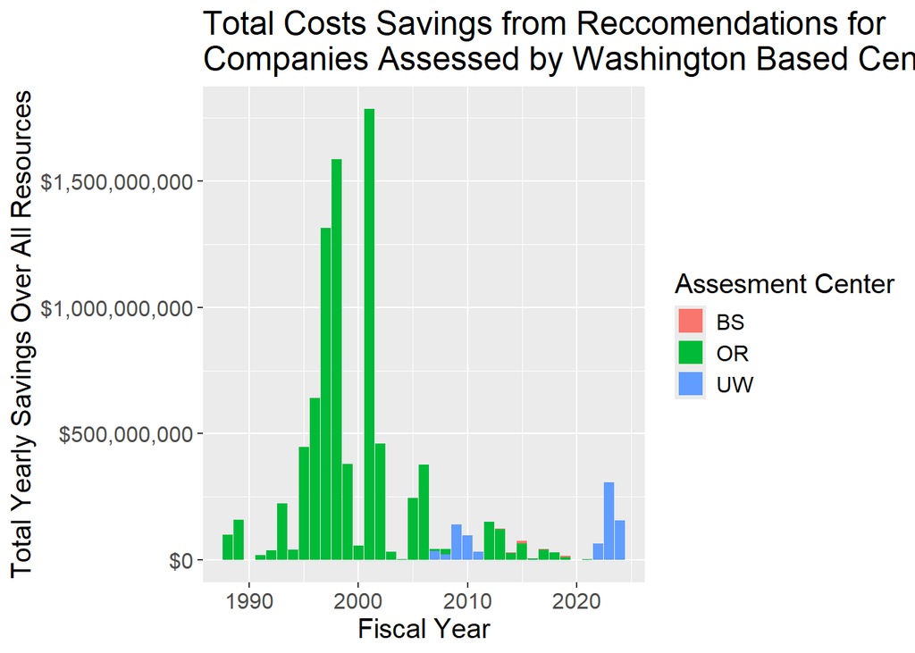

```r
joined_frames %>%
  filter(STATE == "WA") %>%
  select(SUPERID, ID, NAICS, CENTER, FY, PSAVED, SSAVED, TSAVED, QSAVED) %>%
  group_by(CENTER, FY) %>%
  mutate(TOTAL_SAVED = sum(PSAVED, SSAVED, TSAVED, QSAVED, na.rm = TRUE)) %>%
  ggplot(aes(x = FY, y = TOTAL_SAVED, fill = CENTER)) +
  geom_bar(stat = "identity", size = 2) +
  labs(title = "Total Costs Savings from Reccomendations for \nCompanies Assessed by Washington Based Centers",
       x = "Fiscal Year",
       y = "Total Yearly Savings Over All Resources",
       fill = "Assesment Center"
       ) +
  scale_y_continuous(labels = label_dollar()) +
  theme(text = element_text(size=15))
```

## Earning back a percentage of their revenue in Savings

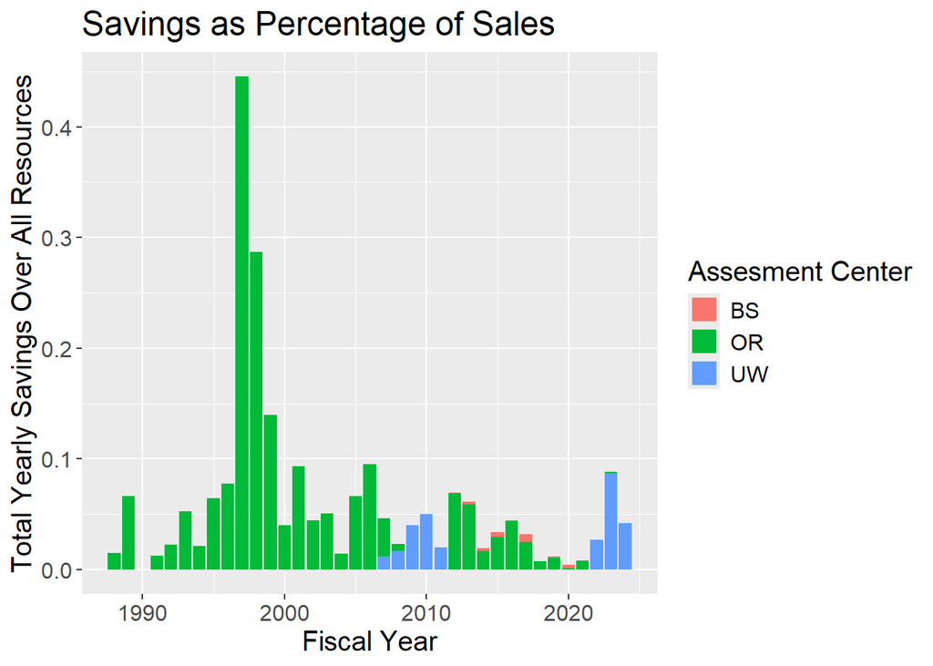

```r
joined_frames %>%
  filter(STATE == "WA") %>%
  select(CENTER, FY, PSAVED, SSAVED, TSAVED, QSAVED, SALES) %>%
  group_by(CENTER, FY) %>%
  mutate(TOTAL_SAVED = sum(PSAVED, SSAVED, TSAVED, QSAVED, na.rm = TRUE)) %>%
  mutate(SALES_TOTAL = sum(SALES, na.rm = TRUE)) %>%
  mutate(SAVED_TO_SALES = TOTAL_SAVED/SALES_TOTAL) %>%
  ggplot(aes(x = FY, y = SAVED_TO_SALES, fill = CENTER)) +
  geom_bar(stat = "identity", size = 2) +
  labs(title = "Savings as Percentage of Sales",
       x = "Fiscal Year",
       y = "Total Yearly Savings Over All Resources",
       fill = "Assesment Center"
       ) +
  #scale_y_continuous(labels = label_dollar()) +
  theme(text = element_text(size=15))
```

[figure not shown]

```r
# Identifying top 5 industries by number of entries
Top5groups <- joined_frames %>%
  filter(!is.na(US_TITLE), !is.na(NAICS)) %>%
  count(US_TITLE) %>%
  arrange(desc(n)) %>%
  slice_head(n = 5)

# Prepare data for graphing, including only top five recommendations per industry
graphed <- joined_frames %>%
  select(US_TITLE, ARC2, PSAVED, SSAVED, TSAVED, QSAVED, Description) %>%
  filter(US_TITLE %in% Top5groups$US_TITLE) %>%
  mutate(TOTAL_SAVED = PSAVED + SSAVED + TSAVED + QSAVED) %>%
  group_by(US_TITLE, ARC2, Description) %>%
  summarize(TOTAL_SAVED = sum(TOTAL_SAVED, na.rm = TRUE), .groups = 'drop') %>%
  arrange(US_TITLE, desc(TOTAL_SAVED)) %>%
  group_by(US_TITLE) %>%
  slice_head(n = 5) %>%
  ungroup() %>%
  mutate(ARC2 = factor(ARC2))  # Factor conversion here for better control

# Create the plot
ggplot(graphed, aes(x = ARC2, y = TOTAL_SAVED, fill = Description)) +
  geom_bar(stat = "identity", position = position_dodge()) +
  facet_wrap(~US_TITLE, scales = "free_x") +
  labs(title = "Top 5 Recommendations by Savings Across Top 5 Industries",
       x = "Recommendation Code", y = "Total Savings", fill = "Recommendation") +
  scale_y_continuous(labels = label_dollar())
```

```r
  theme(axis.text.x = element_text(angle = 45, hjust = 1),
        text = element_text(size = 12))  # Adjusting text size
```

[output not shown]

[output not shown]

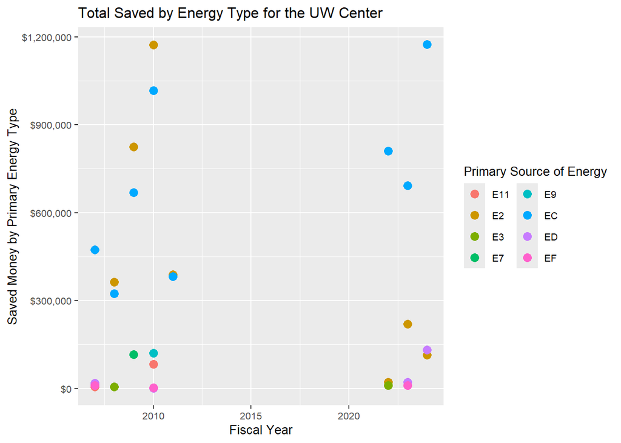

```r
# For UW, Savings per year by industry/energy type
# Going to use Primary Energy type, as is mainly the focus
joined_frames %>%
  filter(CENTER == "UW") %>%
  select(FY, PSOURCCODE, PSAVED) %>%
  filter(substr(PSOURCCODE, 1, 1) == "E") %>%
  group_by(FY, PSOURCCODE) %>%
  summarize(SAVED_SUM = sum(PSAVED, na.rm = TRUE)) %>%
  ggplot(aes(x = FY, y = SAVED_SUM, color = factor(PSOURCCODE))) +
  geom_point(stat = "identity", size = 3) +
  labs(title = "Total Saved by Energy Type for the UW Center",
       x = "Fiscal Year",
       y = "Saved Money by Primary Energy Type",
       color = "Primary Source of Energy"
       ) +
  scale_y_continuous(labels = label_dollar()) +
  theme(text = element_text(size=10)) +
  guides(color = guide_legend(ncol = 2))
```

We can see that in general, the category that has the most savings associated with it is EC, which represents Electrical Consumption, or in other words, how much electricity is used by the company in a given year. However, the reason that this category has the highest savings is because the UW center’s main focus is on electrical consumption. If we also look at the amount of reccomendations for each energy type, we can see that a majority of reccomendations are aimed at improving savings on Electrical Consumption.

```r
# For UW, Savings per year by industry/energy type
# Going to use Primary Energy type, as is mainly the focus
joined_frames %>%
  filter(CENTER == "UW") %>%
  select(FY, PSOURCCODE, PSAVED) %>%
  filter(substr(PSOURCCODE, 1, 1) == "E") %>%
  group_by(PSOURCCODE) %>%
  summarize(count = n())
```

```
## # A tibble: 8 × 2
##   PSOURCCODE count
##   <chr>      <int>
## 1 E11            2
## 2 E2            73
## 3 E3             4
## 4 E7             1
## 5 E9             1
## 6 EC           342
## 7 ED             7
## 8 EF             5
```

If we look at the data without Electrical Consumption:

[output not shown]

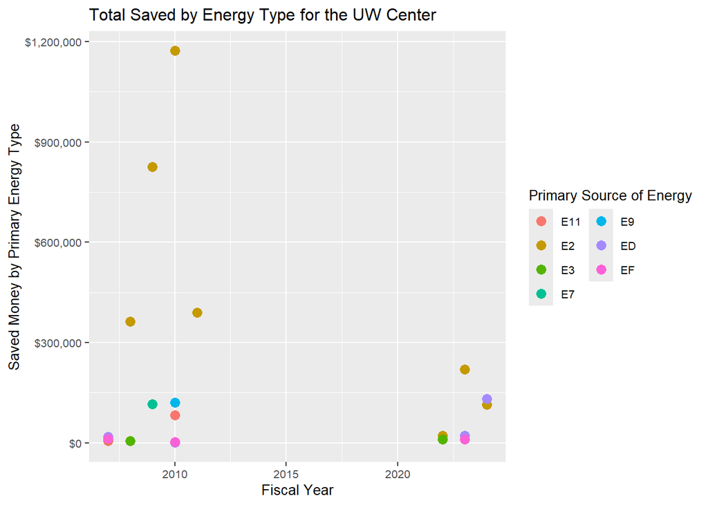

```r
# For UW, Savings per year by industry/energy type
# Going to use Primary Energy type, as is mainly the focus
joined_frames %>%
  filter(CENTER == "UW") %>%
  select(FY, PSOURCCODE, PSAVED) %>%
  filter(substr(PSOURCCODE, 1, 1) == "E") %>%
  filter(PSOURCCODE != "EC") %>%
  group_by(FY, PSOURCCODE) %>%
  summarize(SAVED_SUM = sum(PSAVED, na.rm = TRUE)) %>%
  ggplot(aes(x = FY, y = SAVED_SUM, color = factor(PSOURCCODE))) +
  geom_point(stat = "identity", size = 3) +
  labs(title = "Total Saved by Energy Type for the UW Center",
       x = "Fiscal Year",
       y = "Saved Money by Primary Energy Type",
       color = "Primary Source of Energy"
       ) +
  scale_y_continuous(labels = label_dollar()) +
  theme(text = element_text(size=10)) +
  guides(color = guide_legend(ncol = 2))
```